# NOAA Storm Data Analysis - top severe weather events

Shashank Sane

September 4, 2016

```r
knitr::opts_chunk$set(echo = TRUE, cache = TRUE)
```

### load required libraries

```r
library(dplyr)
```

```r
library(tidyr)
library(ggplot2)
library(lubridate)
library(knitr)
```

### load the data file

```r
## url of the file
fileURL <- "https://d396qusza40orc.cloudfront.net/repdata%2Fdata%2FStormData.csv.bz2"

## Destination file name
DestinationFile <- "FStormData.csv.bz2"

## Download file if does not exist in workspace
if (!file.exists(DestinationFile)){
  download.file(fileURL, DestinationFile)
}

## read file into data frame
dfStormData <- read.csv(DestinationFile,header = TRUE,stringsAsFactors = FALSE)
```

## Data Processing

The NOAA storm database (https://www.ncdc.noaa.gov/stormevents/details.jsp?type=eventtype) indicates that data for all event categories is available only after 1996 onward, so we would select data for period 1996-2011 so that the events which were measured before 1950 do not bias the findings. We also observe that in many events values of all parameters for fatalities, injuries, property damage and crop damage are zero, we would also ignore such data as they do not contribute to the investigation.

```r
## Select only required columns
dfStormData <- select(dfStormData,BGN_DATE,EVTYPE,FATALITIES,INJURIES,PROPDMG,PROPDMGEXP,CROPDMG,CROPDMGEXP)

## Convert BGN_DATE to datetime
dfStormData <- mutate(dfStormData,BGN_DATE = mdy_hms(BGN_DATE))

## All event types are available from 1996 onwards, so filter all events 1996 onwards.
dfStormData <- filter(dfStormData,BGN_DATE >= "1996-01-01")

## Remove all those data cases where fatalities,injuries, property damage and crop damage
## are all zero since this will not impact our analysis.
dfStormData <- filter(dfStormData,!(FATALITIES==0 & INJURIES==0 & PROPDMG==0 & CROPDMG==0))
```

We also observe that while the NOAA storm data indicates 48 event type the actual data contain a lot more events, so we would try to clean event types to ignore minor differences like casing and minor changes in descriptions. We further observe that many event types are of category summary which do not fall into any of the event types so we would remove such cases from our analysis. The event types are referred to from https://www.ncdc.noaa.gov/stormevents/pd01016005curr.pdf, section 2.1.1, page 6 - Storm Data Event table

```r
## Change all the Event values to upper case
dfStormData <- mutate(dfStormData, EVTYPE = toupper(EVTYPE))

## Remove all those event type values which are summmary as this does not belong to any event type
dfStormData <- dfStormData[!grepl("SUMMARY",dfStormData$EVTYPE),]

## Extract event type list
EventList <- dfStormData$EVTYPE

## Try to assign all the different events into the 48 event types defined
EventList[grepl("ASTRONOMICAL LOW|ASTRONOMICAL HIGH TIDE",EventList)] <- "ASTRONOMICAL LOW"
EventList[grepl("AVALANCHE",EventList)] <- "AVALANCHE"
EventList[grepl("BLIZZARD",EventList)] <- "BLIZZARD"
EventList[grepl("COASTAL FLOOD",EventList)] <- "COASTAL FLOOD"
EventList[grepl("COLD/WIND CHILL|COLD",EventList)] <- "COLD/WIND CHILL"
EventList[grepl("DEBRIS FLOW",EventList)] <- "DEBRIS FLOW"
EventList[grepl("DENSE FOG|FOG",EventList)] <- "DENSE FOG"
EventList[grepl("DENSE SMOKE",EventList)] <- "DENSE SMOKE"
EventList[grepl("DROUGHT",EventList)] <- "DROUGHT"
EventList[grepl("DUST DEVIL",EventList)] <- "DUST DEVIL"
EventList[grepl("DUST STORM|BLOWING DUST",EventList)] <- "DUST STORM"
EventList[grepl("EXCESSIVE HEAT",EventList)] <- "EXCESSIVE HEAT"
EventList[grepl("EXTREME COLD/WIND CHILL|EXTREME COLD|EXTREME WINDCHILL",EventList)] <- "EXTREME COLD/WIND CHILL"
EventList[grepl("FLASH FLOOD",EventList)] <- "FLASH FLOOD"
EventList[grepl("FLOOD",EventList)] <- "FLOOD"
EventList[grepl("FROST/FREEZE|AGRICULTURAL FREEZE|DAMAGING FREEZE|EARLY FROST|FREEZE|FROST",EventList)] <- "FROST/FREEZE"
EventList[grepl("FUNNEL CLOUD",EventList)] <- "FUNNEL CLOUD"
EventList[grepl("FREEZING FOG",EventList)] <- "FREEZING FOG"
EventList[grepl("HAIL",EventList)] <- "HAIL"
EventList[grepl("HEAT",EventList)] <- "HEAT"
EventList[grepl("HEAVY RAIN",EventList)] <- "HEAVY RAIN"
EventList[grepl("HEAVY SNOW",EventList)] <- "HEAVY SNOW"
EventList[grepl("HIGH SURF|HEAVY SURF|HEAVY SURF AND WIND|HIGH SURF|HIGH SWELLS|HAZARDOUS SURF",EventList)] <- "HIGH SURF"
EventList[grepl("HIGH WIND",EventList)] <- "HIGH WIND"
EventList[grepl("HURRICANE|TYPHOON|HURRICANE (TYPHOON)",EventList)] <- "HURRICANE (TYPHOON)"
EventList[grepl("ICE STORM",EventList)] <- "ICE STORM"
EventList[grepl("LAKE ",EventList)] <- "LAKE EFFECT"
EventList[grepl("LAKESHORE FLOOD",EventList)] <- "LAKESHORE FLOOD"
EventList[grepl("LIGHTNING",EventList)] <- "LIGHTNING"
EventList[grepl("MARINE HAIL",EventList)] <- "MARINE HAIL"
EventList[grepl("MARINE HIGH WIND",EventList)] <- "MARINE HIGH WIND"
EventList[grepl("MARINE STRONG WIND",EventList)] <- "MARINE STRONG WIND"
EventList[grepl("MARINE THUDERSTORM WIND",EventList)] <- "MARINE THUDERSTORM WIND"
EventList[grepl("RIP CURRENT",EventList)] <- "RIP CURRENT"
EventList[grepl("SEICHE",EventList)] <- "SEICHE"
EventList[grepl("SLEET",EventList)] <- "SLEET"
EventList[grepl("STORM SURGE/TIDE|STORM SURGE",EventList)] <- "STORM SURGE/TIDE"
EventList[grepl("STRONG WIND|GUSTY WIND|GUSTY WINDS|GRADIENT WIND",EventList)] <- "STRONG WIND"
EventList[grepl("THUNDERSTORM|THUNDERSTORM WIND|TSTM WIND|COASTAL STORM|COASTALSTORM",EventList)] <- "THUNDERSTORM WIND"
EventList[grepl("TORNADO",EventList)] <- "TORNADO"
EventList[grepl("TROPICAL DEPRESSION",EventList)] <- "TROPICAL DEPRESSION"
EventList[grepl("TROPICAL STORM",EventList)] <- "TROPICAL STORM"
EventList[grepl("TSUNAMI",EventList)] <- "TSUNAMI"
EventList[grepl("VOLCANIC",EventList)] <- "VOLCANIC ASH"
EventList[grepl("WATERSPOUT",EventList)] <- "WATERSPOUT"
EventList[grepl("WILDFIRE",EventList)] <- "WILDFIRE"
EventList[grepl("WINTER STORM",EventList)] <- "WINTER STORM"
EventList[grepl("WINTER WEATHER",EventList)] <- "WINTER WEATHER"
EventList[grepl("LANDSLIDE|LANDS|MUDSLIDE|MUD SLIDE|ROCK SLIDE",EventList)] <- "LANDSLIDE"

## Assign back the event list
dfStormData$EVTYPE <- EventList

## Convert event type (EVTYPE) to factor variable
dfStormData <- transform(dfStormData, EVTYPE = as.factor(EVTYPE))
```

```r
## group based on event type,  summarise and arrange for fatalities and injuries
dfHealthImpact <- group_by(dfStormData,EVTYPE)%>%
                  summarise(Fatalities= sum(FATALITIES),Injuries = sum(INJURIES))%>%
                  arrange(desc(Fatalities),desc(Fatalities))

## Select top 10 events
dfHealthImpact <- head(dfHealthImpact,10)

## tranform the fatalities anf Injuries into single variable called Type
dfTotalHealthImpact <- gather(dfHealthImpact,Type,Count,-EVTYPE)
```

For Economic Impact look and property damage and crop damage separate and create two sets of data. The events are grouped and summarized base on property damage and crop damage. But first we must calculate the actual valuation based on factor for property damage and crop damage to be derive from column PROPDMGEXP and CROPDMGEXP columns.Alphabetical characters used to signify magnitude include “K” for thousands, “M” for millions, and “B” for billions (page 12- https://www.ncdc.noaa.gov/stormevents/pd01016005curr.pd)

```r
## Create a function to find multiplication factor:
multiple_factor <- function(x)
{
  if(x=="K")
  {
    multiplier=1
  }
  if(x=="M")
  {
    multiplier= 1000
  }
  if(x=="B")
  {
    multiplier=1000000
  }
  else if(x==""|x==0)
  {
    multiplier= 0
  }
  multiplier
}

## Create a new colum property_damage by using lapply to apply function multiple_factor on PROPDMGEXP column
dfStormData$property_damage <- unlist(lapply(dfStormData$PROPDMGEXP,multiple_factor))

## Similarly Create a new colum Crop_damage by using lapply to apply function multiple_factor on CROPDMGEXP column
dfStormData$crop_damage <- unlist(lapply(dfStormData$CROPDMGEXP,multiple_factor))

## Now calculate the actuali property damage and crop damage value by multiplying property_damage and PROPDMG and crop_damage and CROPDMG
dfStormData <- mutate(dfStormData,property_damage =PROPDMG*property_damage,crop_damage = crop_damage*CROPDMG)

## Group by events and find total property damage for each event
dfPropDmg <- group_by(dfStormData,EVTYPE)%>%
             summarise(total_property_damage=sum(property_damage))%>%
             arrange(desc(total_property_damage))


## Group by events and find total crop damage for each event
dfCropDmg <- group_by(dfStormData,EVTYPE)%>%
             summarise(total_crop_damage=sum(crop_damage))%>%
             arrange(desc(total_crop_damage))


## Since the values are scaled in 1000as we set K==1, lets divide by 1000000 to get valuation in billions
dfPropDmg <- mutate(dfPropDmg,total_property_damage=total_property_damage/1000000 )
dfCropDmg <- mutate(dfCropDmg,total_crop_damage=total_crop_damage/1000000 )
```

## Results

### Top 10 Events with the greatest health impact

```r
## take top 10 events for health impact and view them
kable(dfHealthImpact)
```

| EVTYPE | Fatalities | Injuries |
| --- | --- | --- |
| HEAT | 2036 | 7683 |
| TORNADO | 1511 | 20667 |
| FLOOD | 1309 | 8441 |
| LIGHTNING | 651 | 4141 |
| RIP CURRENT | 542 | 503 |
| THUNDERSTORM WIND | 397 | 5071 |
| COLD/WIND CHILL | 372 | 127 |
| HIGH WIND | 236 | 1084 |
| AVALANCHE | 223 | 156 |
| WINTER STORM | 191 | 1292 |

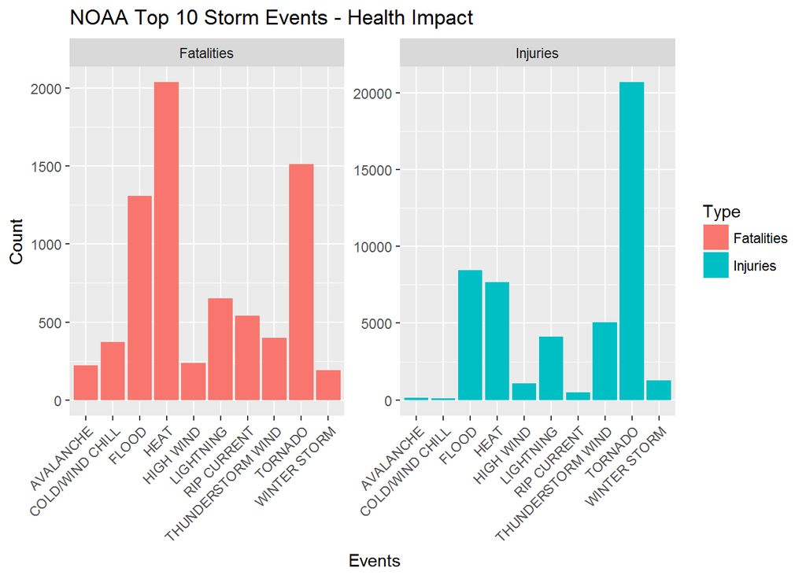

```r
## draw plot to show the top 10 health Impact Events
p <- ggplot(data=dfTotalHealthImpact)
p+theme(axis.text.x = element_text(angle = 45, hjust = 1)) +geom_bar(mapping = aes(x=EVTYPE,y=Count, fill=Type),stat = "identity")+facet_wrap(~Type,scales = "free")+xlab(" Events")+labs(title="NOAA Top 10 Storm Events - Health Impact")
```

### Top 10 events with greatest economic impact

```r
## take the top ten values for both property damage and crop damage
dfPropDmg  <- head(dfPropDmg,10)
dfCropDmg  <- head(dfCropDmg,10)

## View as table
kable(dfPropDmg)
```

| EVTYPE | total_property_damage |
| --- | --- |
| FLOOD | 159.707533 |
| HURRICANE (TYPHOON) | 81.718889 |
| STORM SURGE/TIDE | 47.834724 |
| TORNADO | 24.616946 |
| HAIL | 14.639573 |
| THUNDERSTORM WIND | 7.875088 |
| TROPICAL STORM | 7.642475 |
| HIGH WIND | 5.249675 |
| WILDFIRE | 4.758667 |
| ICE STORM | 3.642249 |

```r
kable(dfCropDmg)
```

| EVTYPE | total_crop_damage |
| --- | --- |
| DROUGHT | 13.3675660 |
| FLOOD | 6.3395751 |
| HURRICANE (TYPHOON) | 5.3501078 |
| HAIL | 2.5615187 |
| FROST/FREEZE | 1.3687610 |
| COLD/WIND CHILL | 1.3397655 |
| THUNDERSTORM WIND | 0.9522964 |
| HEAVY RAIN | 0.7296698 |
| TROPICAL STORM | 0.6777110 |
| HIGH WIND | 0.6335613 |

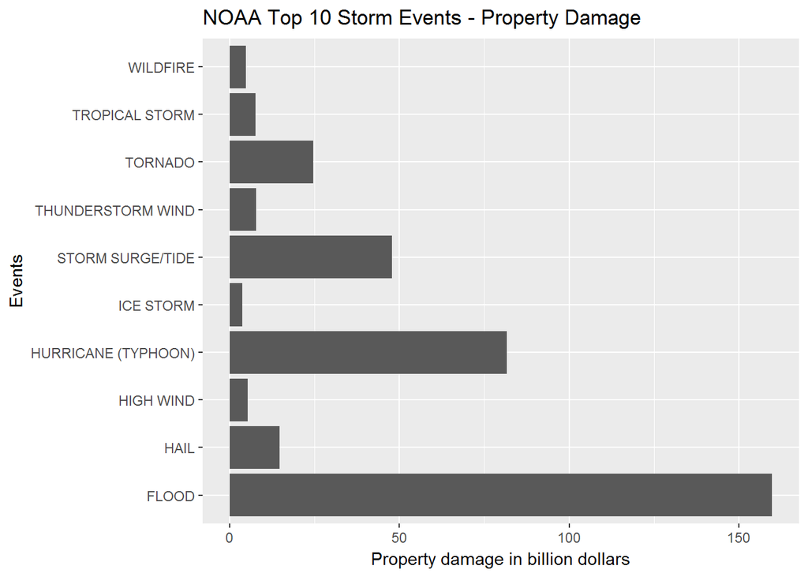

```r
## Create graph for property damage
p <- ggplot(data=dfPropDmg)
p + geom_bar(mapping = aes(x=EVTYPE,y=total_property_damage),stat = "identity")+xlab("Events")+ylab("Property damage in billion dollars")+coord_flip()+labs(title="NOAA Top 10 Storm Events - Property Damage")
```

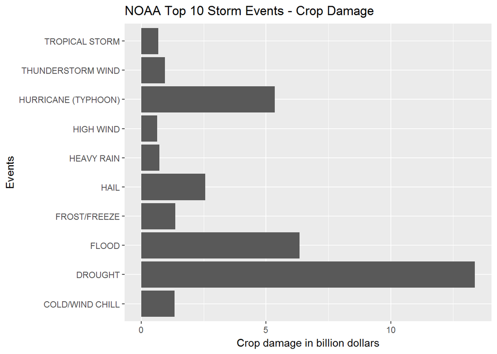

```r
## Create graph for crop damage
p <- ggplot(data=dfCropDmg)
p + geom_bar(mapping = aes(x=EVTYPE,y=total_crop_damage),stat = "identity")+xlab("Events")+ylab("Crop damage in billion dollars")+coord_flip()+labs(title="NOAA Top 10 Storm Events - Crop Damage")
```

The above analysis shows that flood and drought cycle continues to have significant economic impact.